# Human Activity Recognition

## Synopsis

The goal of this project is to build a model that can be used to predict how some persons asked to perform barbell lifts did the exercise. We will also use the model to predict 20 different test cases.  
The data used here is collected from accelerometers on the belt, forearm, arm, and dumbell.  
The data comes from this source : http://groupware.les.inf.puc-rio.br/har and was downloaded from Coursera website.

## Data

The training dataset [Training](https://d396qusza40orc.cloudfront.net/predmachlearn/pml-training.csv) is a set of 160 variables and 19622 observations.  
- The seven first variables describe the context on the exercice : monitoring features  
- The last one, named classe, is the outcome we will try to predict.  
- The other variables are used as predictors.  
The test dataset [Testing](https://d396qusza40orc.cloudfront.net/predmachlearn/pml-testing.csv) has a similar pattern, but his last variable is a problem_id.

## Loading and processing data

### 1 - Set work directory and read CSV data.

```r
setwd("C:/Users/Lydienne/MachineLearning/Project/")
pml.training <- read.csv("pml-training.csv")
pml.testing <- read.csv("pml-testing.csv")
```

### 2 - Select outcome and predictor variables

```r
training <- pml.training [, -c(1,2,3,4,5,6,7)]
testing <- pml.testing [, -c(1,2,3,4,5,6,7)]
```

### 3 - Check training and testing data

```r
str(training)
```

```
## 'data.frame':    19622 obs. of  153 variables:
##  $ roll_belt               : num  1.41 1.41 1.42 1.48 1.48 1.45 1.42 1.42 1.43 1.45 ...
##  $ pitch_belt              : num  8.07 8.07 8.07 8.05 8.07 8.06 8.09 8.13 8.16 8.17 ...
##  $ yaw_belt                : num  -94.4 -94.4 -94.4 -94.4 -94.4 -94.4 -94.4 -94.4 -94.4 -94.4 ...
##  $ total_accel_belt        : int  3 3 3 3 3 3 3 3 3 3 ...
##  $ kurtosis_roll_belt      : Factor w/ 397 levels "","-0.016850",..: 1 1 1 1 1 1 1 1 1 1 ...
##  $ kurtosis_picth_belt     : Factor w/ 317 levels "","-0.021887",..: 1 1 1 1 1 1 1 1 1 1 ...
##  $ kurtosis_yaw_belt       : Factor w/ 2 levels "","#DIV/0!": 1 1 1 1 1 1 1 1 1 1 ...
##  $ skewness_roll_belt      : Factor w/ 395 levels "","-0.003095",..: 1 1 1 1 1 1 1 1 1 1 ...
##  $ skewness_roll_belt.1    : Factor w/ 338 levels "","-0.005928",..: 1 1 1 1 1 1 1 1 1 1 ...
##  $ skewness_yaw_belt       : Factor w/ 2 levels "","#DIV/0!": 1 1 1 1 1 1 1 1 1 1 ...
##  $ max_roll_belt           : num  NA NA NA NA NA NA NA NA NA NA ...
##  $ max_picth_belt          : int  NA NA NA NA NA NA NA NA NA NA ...
##  $ max_yaw_belt            : Factor w/ 68 levels "","-0.1","-0.2",..: 1 1 1 1 1 1 1 1 1 1 ...
##  $ min_roll_belt           : num  NA NA NA NA NA NA NA NA NA NA ...
```

[output cut: 86 more lines]

```r
str(testing)
```

```
## 'data.frame':    20 obs. of  153 variables:
##  $ roll_belt               : num  123 1.02 0.87 125 1.35 -5.92 1.2 0.43 0.93 114 ...
##  $ pitch_belt              : num  27 4.87 1.82 -41.6 3.33 1.59 4.44 4.15 6.72 22.4 ...
##  $ yaw_belt                : num  -4.75 -88.9 -88.5 162 -88.6 -87.7 -87.3 -88.5 -93.7 -13.1 ...
##  $ total_accel_belt        : int  20 4 5 17 3 4 4 4 4 18 ...
##  $ kurtosis_roll_belt      : logi  NA NA NA NA NA NA ...
##  $ kurtosis_picth_belt     : logi  NA NA NA NA NA NA ...
##  $ kurtosis_yaw_belt       : logi  NA NA NA NA NA NA ...
##  $ skewness_roll_belt      : logi  NA NA NA NA NA NA ...
##  $ skewness_roll_belt.1    : logi  NA NA NA NA NA NA ...
##  $ skewness_yaw_belt       : logi  NA NA NA NA NA NA ...
##  $ max_roll_belt           : logi  NA NA NA NA NA NA ...
##  $ max_picth_belt          : logi  NA NA NA NA NA NA ...
##  $ max_yaw_belt            : logi  NA NA NA NA NA NA ...
##  $ min_roll_belt           : logi  NA NA NA NA NA NA ...
```

[output cut: 86 more lines]

- result : 153 variables (one outcome and 152 predictors)
- training data : some variables are “Factor” instead of “Num”, we need to transform them so that they may be used in a proper way.
- testing data : some variables are “logical” instead of “Num”, a transformation is needed too.

### 4 - Transform training and testing data

```r
for (i in 1:152) if(class(training[,i])=="factor") training[,i] <- as.numeric(as.character(training[,i]))
for (i in 1:152) if(class(testing[,i])=="logical") testing[,i] <- as.numeric(as.character(testing[,i]))
```

### 5 - Preprocessing and Prinicpal Components

#### 5.1 Remove outcome variable and determine PC

```r
library("caret")
trainData1 <- training[,-153]
summary(prcomp(trainData1, scale = TRUE))
```

```
## Error: cannot rescale a constant/zero column to unit variance
```

#### 5.2 Variables with mean equal to NA

```r
means <- colMeans(trainData1, na.rm = TRUE)
which(is.na(means[]) )
```

```
##     kurtosis_yaw_belt     skewness_yaw_belt kurtosis_yaw_dumbbell
##                     7                    10                    82
## skewness_yaw_dumbbell  kurtosis_yaw_forearm  skewness_yaw_forearm
##                    85                   120                   123
```

#### 5.3 Conclusion

Preprocessing is not possible because we have missing value in some variables.  
So we are going to build model without preprocessing

### 6 - Building Model

#### 6.1 Remove variables with NA values

```r
trainData <- training[,-153]
testData <- testing[,-153]
means <- colMeans(testData, na.rm = TRUE)
testData <- testData[,which(!is.na(means[]))]
trainData <- data.frame(cbind(trainData[,which(!is.na(means[]))], classe=training$classe))
```

#### 6.2 Apply RPART with CARET package and plot result

```r
library("rattle")
set.seed(1)
CART <- train(classe ~ . ,method="rpart",data=trainData)
print("Classification And Regression Tree Summary")
```

```
## [1] "Classification And Regression Tree Summary"
```

```r
CART
```

```
## CART
##
## 19622 samples
##    52 predictors
##     5 classes: 'A', 'B', 'C', 'D', 'E'
##
## No pre-processing
## Resampling: Bootstrapped (25 reps)
##
## Summary of sample sizes: 19622, 19622, 19622, 19622, 19622, 19622, ...
##
## Resampling results across tuning parameters:
##
##   cp    Accuracy  Kappa  Accuracy SD  Kappa SD
##   0.04  0.5       0.4    0.02         0.03
##   0.06  0.4       0.3    0.06         0.1
##   0.1   0.3       0.06   0.04         0.06
##
## Accuracy was used to select the optimal model using  the largest value.
## The final value used for the model was cp = 0.04.
```

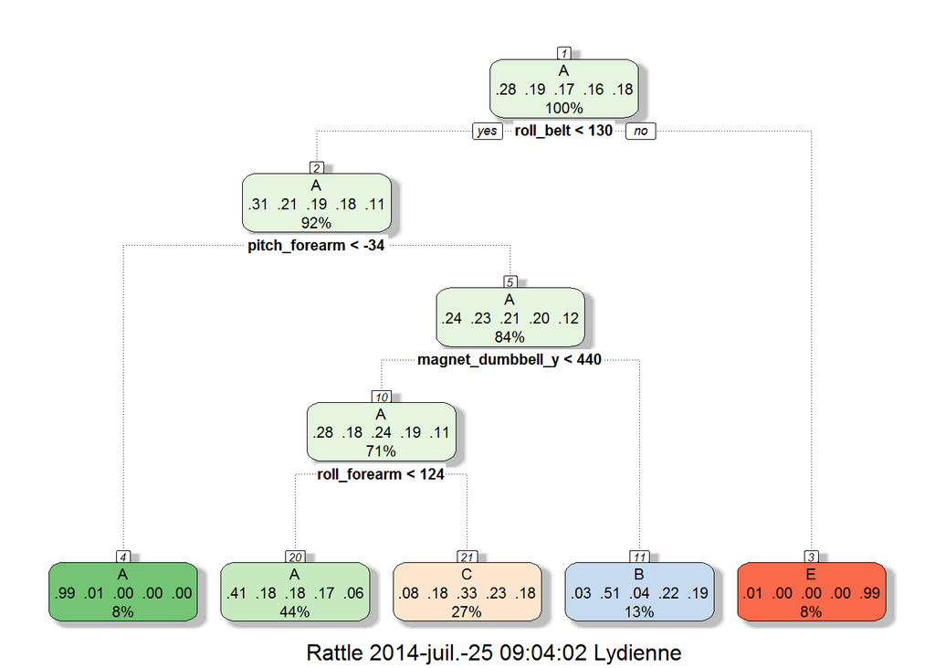

```r
##print(CART$finalModel)
fancyRpartPlot(CART$finalModel)
```

#### 6.3 Apply RPART with TREE package and plot result

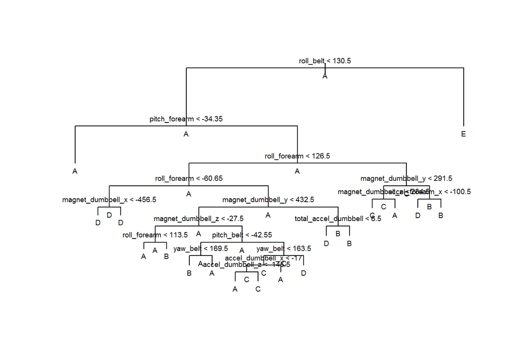

```r
library("tree")
set.seed(2)
Tree1 <- tree(classe ~ . ,method="rpart",data=trainData)
plot(Tree1)
text(Tree1, all=TRUE, cex=.6)
```

### 7 - Prediction

```r
answers <- predict(CART,testData)
answers
```

```
##  [1] C A C A A C C A A A C C C A C A A A A C
## Levels: A B C D E
```

```r
source("pml_write_files.R")
pml_write_files(answers)
```